← Back to ML Fundamentals • Week 4 of 0–15

# Week 4 — ML Fundamentals

[Open in Colab](https://colab.research.google.com/github/sanketn26/learn-ml/blob/main/notebooks/week-04-saas.ipynb) [Open in VS Code](https://vscode.dev/github/sanketn26/learn-ml/blob/main/notebooks/week-04-saas.ipynb) Open in Jupyter [Download .ipynb](https://raw.githubusercontent.com/sanketn26/learn-ml/main/notebooks/week-04-saas.ipynb)

### 📝 How to Run This Notebook Locally

**1. Clone the repository:**  
`git clone https://github.com/sanketn26/learn-ml.git && cd learn-ml`

**2. Set up environment:**  
`python3 -m venv venv && source venv/bin/activate`  
`pip install jupyter notebook`

**3. Install course dependencies:**  
`pip install numpy pandas scikit-learn matplotlib scipy seaborn`  
`pip install torch`

**4. Open the notebook:**  
`jupyter notebook notebooks/week-04-saas.ipynb`

# Week 4 — “Is This Real, or Just Noise?”

**Course:** Applied ML Foundations for SaaS Analytics  
**Who this is for:** Engineers who ship A/B tests and get asked “but is it significant?” You do not need a stats degree.

We will **not** memorize a zoo of tests. We will make one decision carefully, then keep a flowchart for later.

## 🎯 What you will be able to do

- Translate a p-value into a sentence a PM cannot misuse
- Run the actual “8 / 50 vs 12 / 60” launch question — and see it fail to reject
- Draw a confidence interval as “a range of plausible true rates”
- Know which test matches your column types
- Refuse to ship on p < 0.05 alone

**Think of it like… a code review, or a courtroom.**

The **null hypothesis** is the boring default: “these two plans churn the same; the difference is luck.” You do *not* prove the new plan works. You ask: *if they were the same, how often would luck produce a gap this big?* That frequency is the p-value. Innocent until proven guilty. High bar to convict.

```python
%matplotlib inline
from pathlib import Path
import sys

import numpy as np
import pandas as pd
import matplotlib.pyplot as plt

# Make the shared style kit importable whether you launch from notebooks/ or repo root
for _p in [Path.cwd(), Path.cwd() / "notebooks", Path.cwd().parent]:
    if (_p / "course_style.py").exists():
        sys.path.insert(0, str(_p))
        break

from course_style import apply_style, setup_plots, find_data_dir

apply_style()
setup_plots()
DATA = find_data_dir()
print(f"Data folder: {DATA}")
print("Laptop mode: no GPU required. Models use a sample so each week finishes in a few minutes on CPU.")

from scipy import stats
```

```
Data folder: /Users/sanketnaik/workspace/learn-ml/data
Laptop mode: no GPU required. Models use a sample so each week finishes in a few minutes on CPU.
```

## 🏢 Scenario — should we roll out Premium?

Early data:

| Plan | Churned | Customers | Rate |
| --- | --- | --- | --- |
| Premium | 8 | 50 | **16%** |
| Standard | 12 | 60 | **20%** |

A PM sees “Premium is better.” An engineer asks: **with this few customers, how often would a 4-point gap appear by coin-flip?**

**Engineer mental model**

A p-value is *not* “the probability we are wrong.” It is not “the probability Premium is worse.” It is: **how often a world with no real difference produces a result this spicy.** Same idea as “how often would this flaky test fail on a green build?”

## Visual: luck can look like a win

We will fake 10,000 worlds where both plans truly churn at 18%. In each world, draw 50 + 60 customers. Plot the Premium − Standard gap. Then mark the gap we actually saw (−4 points).

```
findfont: Failed to find font weight semibold, now using 700.
```

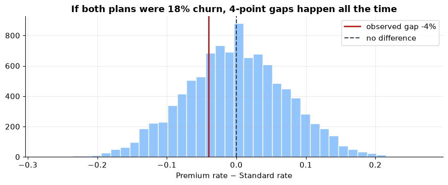

```
Share of fake worlds with a gap at least this big: 0.60
That is a p-value, built with a for-loop in your head instead of a formula.
```

```python
rng = np.random.default_rng(42)
true_rate = 0.18
n_prem, n_std = 50, 60
observed_gap = 8 / 50 - 12 / 60  # -0.04

sim_gaps = rng.binomial(n_prem, true_rate, 10_000) / n_prem - rng.binomial(n_std, true_rate, 10_000) / n_std

fig, ax = plt.subplots(figsize=(9, 3.8))
ax.hist(sim_gaps, bins=40, color="#93c5fd", edgecolor="white")
ax.axvline(observed_gap, color="#b91c1c", lw=2, label=f"observed gap {observed_gap:.0%}")
ax.axvline(0, color="#334155", ls="--", label="no difference")
ax.set_title("If both plans were 18% churn, 4-point gaps happen all the time")
ax.set_xlabel("Premium rate − Standard rate")
ax.legend()
plt.tight_layout()
plt.show()

p_two_sided = (np.abs(sim_gaps) >= abs(observed_gap)).mean()
print(f"Share of fake worlds with a gap at least this big: {p_two_sided:.2f}")
print("That is a p-value, built with a for-loop in your head instead of a formula.")
```

## The same answer, with a library test

Chi-squared (or Fisher’s exact, for tiny counts) is the grown-up version of the histogram above.

**Math, translated**

```python
table = np.array([[8, 42],   # premium: churned, retained
                  [12, 48]])  # standard
chi2, p, dof, expected = stats.chi2_contingency(table)
print("Chi-squared p-value on the 8/50 vs 12/60 story:", round(p, 3))
print("Expected counts if plans were equal:\n", expected.round(1))
print("\nVerdict: p is large. We do NOT have enough evidence to declare Premium better.")
print("Ship decision: keep collecting data. Do not rewrite billing based on 110 customers.")
```

```
Chi-squared p-value on the 8/50 vs 12/60 story: 0.769
Expected counts if plans were equal:
 [[ 9.1 40.9]
 [10.9 49.1]]

Verdict: p is large. We do NOT have enough evidence to declare Premium better.
Ship decision: keep collecting data. Do not rewrite billing based on 110 customers.
```

## Now the full CloudWave table

Same question, real `subscriptions.csv`. More customers → the same 4-point gap would be a much bigger deal.

**Visual cue — which test?**

**Category vs category** (plan × churned) → chi-squared.  
**Number vs 2 groups** (MRR for churned vs not) → t-test (or Mann-Whitney if the histogram is a whale-tail).  
**Number vs 3+ groups** (usage by region) → ANOVA, then look at the picture before you trust the p.

```
Counts:
 is_churned      0     1
plan_type
enterprise   2495   104
free        22528  2358
pro          7263   285
starter     14368   599

Chi-squared p-value across all plans: 5.42e-133

95% range of plausible churn rates:
             rate     lo     hi        n
plan
enterprise  0.040  0.033  0.048   2599.0
free        0.095  0.091  0.098  24886.0
pro         0.038  0.034  0.042   7548.0
starter     0.040  0.037  0.043  14967.0
```

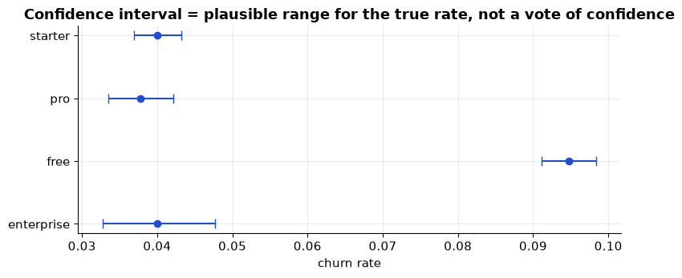

```python
subs = pd.read_csv(DATA / "subscriptions.csv")

ct = pd.crosstab(subs["plan_type"], subs["is_churned"])
print("Counts:\n", ct)
chi2, p, dof, expected = stats.chi2_contingency(ct)
print(f"\nChi-squared p-value across all plans: {p:.2e}")

rates = subs.groupby("plan_type")["is_churned"].agg(["mean", "count"])
# Wilson-style interval via the binomial (good enough picture)
cis = []
for plan, row in rates.iterrows():
    lo, hi = stats.binom.interval(0.95, int(row["count"]), row["mean"])
    cis.append((plan, row["mean"], lo / row["count"], hi / row["count"], row["count"]))
ci_df = pd.DataFrame(cis, columns=["plan", "rate", "lo", "hi", "n"]).set_index("plan")
print("\n95% range of plausible churn rates:")
print(ci_df.round(3))

fig, ax = plt.subplots(figsize=(8, 3.6))
y = np.arange(len(ci_df))
ax.errorbar(ci_df["rate"], y,
            xerr=[ci_df["rate"] - ci_df["lo"], ci_df["hi"] - ci_df["rate"]],
            fmt="o", color="#1d4ed8", capsize=4)
ax.set_yticks(y, ci_df.index)
ax.set_xlabel("churn rate")
ax.set_title("Confidence interval = plausible range for the true rate, not a vote of confidence")
plt.tight_layout()
plt.show()
```

## A number vs two groups — do churners pay less?

T-test asks: “is the difference in average MRR bigger than the usual jitter in averages?”

```
Mean MRR churned=29.2  kept=51.1
Welch t-test p=4.54e-40
```

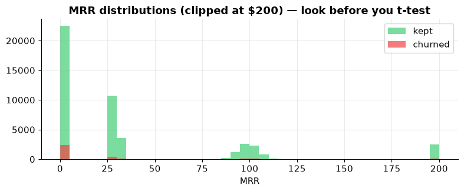

```
Free users have MRR = 0 and churn more. The t-test may just be rediscovering the free plan.
```

```python
churned = subs.loc[subs["is_churned"] == 1, "mrr"]
kept = subs.loc[subs["is_churned"] == 0, "mrr"]
t, p = stats.ttest_ind(churned, kept, equal_var=False)
print(f"Mean MRR churned={churned.mean():.1f}  kept={kept.mean():.1f}")
print(f"Welch t-test p={p:.3g}")

fig, ax = plt.subplots(figsize=(8, 3.4))
ax.hist(kept.clip(upper=200), bins=40, alpha=0.6, label="kept", color="#22c55e")
ax.hist(churned.clip(upper=200), bins=40, alpha=0.7, label="churned", color="#ef4444")
ax.set_title("MRR distributions (clipped at $200) — look before you t-test")
ax.set_xlabel("MRR")
ax.legend()
plt.tight_layout()
plt.show()

print("Free users have MRR = 0 and churn more. The t-test may just be rediscovering the free plan.")
```

**Watch out**

- **p-hacking:** 20 slices of the data will produce one “p < 0.05” by accident. Pre-register the question, or treat extra slices as exploration.
- **Significance ≠ importance:** with 50,000 rows, a 0.2% churn gap can be “significant” and still not worth an engineering quarter.
- **CI overlap** is a sloppy shortcut. Look at the interval on the *difference*, or just look at dollars.

**Ship / don’t ship**

Ship when (1) the interval on the lift is mostly above your *business* threshold, (2) you have looked at the chart, (3) a second slice (another month, another region) rhymes. p < 0.05 is a filter, not a launch button.

## ✍️ Exercises

**1. Paid-only chi-squared.** Drop `plan_type == "free"`. Is churn still different across starter / pro / enterprise? Predict the answer before you run it.

**2. Sentiment.** Load `feedback.json` (`lines=True`). Is mean `sentiment_score` different for `category == "bug"` vs `"praise"`? Which test? (Two groups, a number → t-test. Then look at the histogram.)

**3. Sample size gut check.** Keep the 16% vs 20% rates. How many customers per plan (equal n) until a simulation p-value usually drops under 0.05? Try n = 100, 400, 1000.

## 🤔 Reflection

1. Explain a p-value to a PM in one sentence without the word “significant.”
2. Why did 8/50 vs 12/60 fail, while the full table’s plan comparison did not?
3. You ran 12 ad-hoc tests on one Friday. How many “wins” do you expect by luck at α = 0.05?

## 🔗 Next week

Feature engineering — turning Customer 360 columns into the **API contract** of a model, without leaking the future into the past.

← Previous Week Back to ML Fundamentals Next Week →